# Experiments for RQ 5

# Research Question 5

The question is: *“What is the impact of univariate first-order Hidden Markov Models for commit classification?”*

For this experiment, for the training, we will rely on the dataset **`treeX_L`**, which is a hierarchical dataset that features some of the commits’ as labelled by Levin et al. and adjacent commits labelled by us, using detailed re-engineered rules. This way, we get a few *chains* of commits. Each commit in the **`treeX_L`** dataset is labelled, and has the extended attributes attached. We cannot use the attributes from **`x1151`**, as the commits labelled in that dataset are non-consecutive.

We are going to analyze those chains, in order to construct state-transition matrices, and initial state probability distribution matrices. Then, for each of the features, using some resolution, we will discretize the feature and fit a univariate HMM. Then we will learn more about which features are suitable for labelling commits based on their predecessor.

```r
source("../helpers.R")
install.packagesCond("knitr")
knitr::opts_chunk$set(rows.print=25, cols.print=15)
```

# Prepare the datasets and functions

We will load the data from the view `rq5_treex`. Then, we will build a dictionary so that it becomes easier to connect commits to their siblings.

```r
install.packagesCond("caret")
library("caret")
install.packagesCond("e1071")
library("e1071")
install.packagesCond("HMM")
library("HMM")
treeXL <- getDataset("rq5_treex", removeUnwantedColums = FALSE) # we do this manually
treeXL$label <- as.factor(treeXL$label)
treeXL$project <- as.factor(treeXL$project)
removeNames <- c(
  "branch", "reasonOrRule", "RepoPathOrUrl",
  "AuthorName", "CommitterName", "AuthorTime",
  "CommitterTime", "Message",
  "AuthorEmail", "CommitterEmail",
  "AuthorNominalLabel", "CommitterNominalLabel")
treeXL <- treeXL[, !names(treeXL) %in% removeNames]
```

The base-dataset `treeX_L` is now prepared. However, we want a list of chains of commits. Generating these is next. From this indexed list, we can build chains. The begin of a chain is marked by a commit that does not find a parent itself in the loaded dataset. Please note that some commits are in fact the initial commits on their branch, but this is not a necessity.

## Builder for Commit chains

We will define a function, that build a list of chains of commits. The input is a dataset that contains commits that carry both their own ID and the ID of their parent.

```r
treeXinitialCommits <- buildCommitChains(treeXL, "commitId", "ParentCommitSHA1s", returnOnlyInitial = TRUE)
treeXChains <- buildCommitChains(treeXL, "commitId", "ParentCommitSHA1s", returnOnlyInitial = FALSE)
```

# HMM Experiments

Now we have sufficiently prepared the data, let’s use it to create univariate HMMs.

## The non-treeX commits

Those we will fetch now, although they are only needed later when we compute discrete events from one of the random variables.

```r
nonTreeXwithGex <- getDataset("rq5_non_treex_gex", removeUnwantedColums = F)
treeXall5GensFlat <- getDataset("rq5_non_treex_5_gens_gex")
```

## Initial State probabilities

```r
temp <- treeXL$label
tempTable <- table(temp)
startProbs <- tempTable / sum(tempTable)
startProbs
```

```
temp
        a         c         p
0.2160279 0.2369338 0.5470383
```

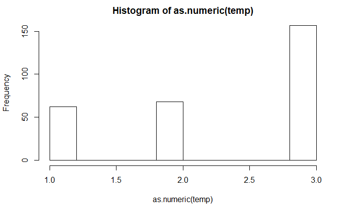

```r
# Show the distribution
hist(as.numeric(temp))
```

```r
tempTable
```

```
temp
  a   c   p
 62  68 157
```

```r
states <- names(tempTable)
states
```

```
[1] "a" "c" "p"
```

## State transition probabilities

Again, we do this empirically, by walking each chain of commits and counting how often each state transitions into each other state.

```r
transProbs <- matrix(nrow = length(states), ncol = length(states), data = 0)
rownames(transProbs) <- states
colnames(transProbs) <- states
for (chain in names(treeXChains)) {
  # a dataframe with parent on top, going down to the children
  parentDs <- treeXChains[[chain]]

  for (i in 1:(nrow(parentDs) - 1)) {
    parent <- parentDs[i, ]
    child <- parentDs[i + 1, ]

    # In our matrix, we have parents as row names, and children as column names
    pIdx <- match(as.character(parent$label), states)
    cIdx <- match(as.character(child$label), states)

    # Now increase the counter in cell pIdx,cIdx by one, marking an observed
    # transition between these two states
    transProbs[pIdx, cIdx] <- transProbs[pIdx, cIdx] + 1
  }
}
transProbs
```

```
   a  c  p
a 23 16 19
c  7 23 26
p 16 18 88
```

```r
sum(transProbs)
```

```
[1] 236
```

```r
# Next thing, we have to normalize each row in the matrix so that its sum is 1:
for (state in states) {
  transProbs[state, ] <- transProbs[state, ] / sum(transProbs[state, ])
}
transProbs
```

```
          a         c         p
a 0.3965517 0.2758621 0.3275862
c 0.1250000 0.4107143 0.4642857
p 0.1311475 0.1475410 0.7213115
```

## Emission probabilities

For these one-dimensional univariate HMM experiments, we are going to discretize all features and try an HMM on each of them. All of our features (except for “Density” and “AffectedFilesRatioNet”) are discrete, positive and follow a geomtric distribution. We will put them into buckets, which will correspond to events.

```r
generateBucket <- function(data, numBuckets, inclMinVal = NULL, exclMaxVal = NULL) {
  if (is.null(inclMinVal)) {
    inclMinVal <- min(data)
  }
  if (is.null(exclMaxVal)) {
    exclMaxVal <- max(data)
  }

  dataCut <- data[data >= inclMinVal & data < exclMaxVal]
  dataRange <- max(exclMaxVal) - min(dataCut)

  # We will prepend a bucket for all values < inclMinVal
  # and append one bucket for all values >= exclMaxVal
  dataStep <- dataRange / (numBuckets - 2)

  allRanges <- list(c(.Machine$double.xmin, inclMinVal))

  intStart <- min(dataCut)
  intStop <- intStart + dataStep
  for (i in c(2:(numBuckets))) {
    # Generate an interval [intStart, intStop)
    allRanges[[i]] <- c(intStart, intStop)

    intStart <- intStart + dataStep
    intStop <- intStop + dataStep
  }

  allRanges[[numBuckets]] <- c(exclMaxVal, .Machine$double.xmax)

  return(allRanges)
}
# 'data' must be a vector with the data
# 'dataState' must be a vector that assigns a state to each value in data
generateEmmissionProbMatrix <- function(states, buckets, data, dataState) {
  eProbs <- matrix(nrow = length(states), ncol = length(buckets), data = 0)
  states <- as.character(states)
  eNames <- c()
  for (i in 1:length(buckets)) {
    eNames <- c(eNames, paste("E", i, sep = "_"))
  }

  colnames(eProbs) <- eNames
  rownames(eProbs) <- states

  for (state in states) {
    temp <- data[as.character(dataState) == state]

    for (bIdx in 1:length(buckets)) {
      # range, as [inc, ex)
      r <- buckets[[bIdx]]
      eName <- eNames[bIdx]
      eProbs[state, eName] <- eProbs[state, eName] +
        length(temp[temp >= r[1] & temp < r[2]])
    }
  }

  for (state in states) {
    eSum <- sum(eProbs[state, ])
    if (eSum > 0) {
      eProbs[state, ] <- eProbs[state, ] / eSum
    }
  }

  return(eProbs)
}
```

Now we will select the features that we plan on discretize into events.

```r
selectedFeatures <- names(nonTreeXwithGex)
selectedFeatures <- selectedFeatures[grepl("^(Number|Minutes|Dens|Aff)", selectedFeatures)]
```

## Evaluate univariate HMM models

Let’s define a function that runs various models on a feature and reports the accuracy.

```r
eventNameForValue <- function(buckets, eventNames, value) {
  for (i in 1:length(buckets)) {
    valRange <- buckets[[i]]
    if (value >= valRange[1] & value < valRange[2]) {
      return(eventNames[i])
    }
  }
  stop("Should not get here!")
}
rq5_treex_and_non_treex <- getDataset("rq5_treex_and_non_treex", FALSE)
```

```r
evalHmmModel <- function(states, startProbs, startProbsName, transProbs, transProbsName, data, chains, featureCol, featureLabelCol, bucketLength, generateBucket, generateEmmissionProbMatrix) {
  exclVal <- quantile(data[, featureCol], c(1 - (1 / bucketLength)))
  buckets <- generateBucket(data[, featureCol], bucketLength, NULL, exclVal)

  eProbs <- generateEmmissionProbMatrix(
    states, buckets, data[, featureCol], data[, featureLabelCol])
  eNames <- colnames(eProbs)

  hmm <- initHMM(
    states, eNames, startProbs, transProbs, emissionProbs = eProbs)

  listChainNames <- c()
  listZeroR <- c()
  listAcc <- c()
  listKappa <- c()
  listLevinCorrect <- c()
  listLastcorrect <- c()
  theFactor <- factor(c(), levels = states)

  for (chainName in names(chains)) {
    listChainNames <- c(listChainNames, chainName)
    chain <- chains[[chainName]] # a data.frame

    events <- c()
    trueLabels <- c()
    for (i in 1:nrow(chain)) {
      commit <- chain[i, ]
      events <- c(events, eventNameForValue(buckets, eNames, commit[[featureCol]]))
      trueLabels <- c(trueLabels, as.character(commit[[featureLabelCol]]))
    }

    predLabels <- factor(viterbi(hmm, events), levels = levels(theFactor))
    trueLabels <- factor(trueLabels, levels = levels(theFactor))


    listZeroR <- c(listZeroR,
      # We are computing the zeroR for the current chain!
      confusionMatrix(predictZeroR(trueLabels), trueLabels)$overall[["Accuracy"]])

    cm <- confusionMatrix(predLabels, trueLabels, mode = "everything")
    listAcc <- c(listAcc, cm$overall[["Accuracy"]])
    listKappa <- c(listKappa, cm$overall[["Kappa"]])
    listLastcorrect <- c(listLastcorrect, tail(predLabels, n=1) == tail(trueLabels, n=1))

    # Let's check if the commit labelled by Levin et al. was correct!
    levinCommitNumber <- which(chain$labelledBefore == 1)
    levinCorrValue <- 0
    if (length(levinCommitNumber) == 0) {
      levinCorrValue <- -1 # no such commit (some chains may be labelled w/o such a commit)
    } else {
      if (predLabels[levinCommitNumber] == trueLabels[levinCommitNumber]) {
        levinCorrValue <- 1
      } else {
        levinCorrValue <- 0
      }
    }

    listLevinCorrect <- c(listLevinCorrect, levinCorrValue)
  }

  len <- length(listZeroR)
  return(data.frame(
    event = rep(featureCol, len),
    bucketLen = rep(bucketLength, len),
    startProbsName = rep(startProbsName, len),
    transProbsName = rep(transProbsName, len),

    chainName = listChainNames,
    zeroR = listZeroR,
    accuracy = listAcc,
    kappa = listKappa,
    lastCorr = listLastcorrect,
    levinCorr = listLevinCorrect,

    stringsAsFactors = FALSE
  ))
}
```

### Permutations

Within each evaluation, we will test all chains, and each evaluation shall return a dictionary, that contains the name of the feature, a list of zeroR-values, a list of accuracies and a list of Kappas (where each of these values corresponds to one chain).

```r
genTransProbs <- function(random = TRUE, labels = c('a', 'c', 'p')) {
  l <- length(labels)
  m <- 0
  if (random) {
    m <- t(replicate(l, runif.sum(l)))
  } else {
    m <- t(replicate(l, rep(1/l, l)))
  }

  rownames(m) <- labels
  colnames(m) <- labels
  return(m)
}
genStartProbs <- function(random = TRUE, labels = c('a', 'c', 'p')) {
  l <- length(labels)
  if (random) {
    return(runif.sum(l))
  }
  return(rep(1/l, l))
}
```

```r
runif.sum <- function(n){
  x <- sort(runif(n-1))
  c(x,1) - c(0,x)
}
set.seed(1337)
dofStartProbs <- list(
  emp = as.vector(startProbs),
  same = genStartProbs(random = FALSE),
  r1 = genStartProbs(),
  r2 = genStartProbs(),
  r3 = genStartProbs(),
  r4 = genStartProbs(),
  r5 = genStartProbs()
)
set.seed(1337)
dofTransProbs <- list(
  emp = transProbs,
  same = genTransProbs(random = FALSE),
  r1 = genTransProbs(),
  r2 = genTransProbs(),
  r3 = genTransProbs(),
  r4 = genTransProbs(),
  r5 = genTransProbs()
)
dofBuckets <- seq(10, 100, 5)
dofEvents <- c(selectedFeatures)
```

Let’s run all the permutations:

```r
install.packagesCond("foreach")
library("foreach")
install.packagesCond("parallel")
library("parallel")
install.packagesCond("doParallel")
library("doParallel")
if (file.exists("allResults.rds")) {
  allResults <- readRDS("allResults.rds")
} else {
  cluster <- makeCluster(detectCores())
  registerDoParallel(cluster)

  allResults <- foreach(
    eventName = dofEvents, .packages = c("caret", "parallel", "doParallel", "foreach", "HMM"), .combine = "rbind") %dopar%
  {
    eventResults <- data.frame(matrix(nrow = 0, ncol = 10), stringsAsFactors = FALSE)
    colnames(eventResults) <- c(
      "event", "bucketLen", "startProbsName", "transProbsName", "chainName", "zeroR", "accuracy", "kappa", "lastCorr", "levinCorr")

    for (spName in names(dofStartProbs)) {
      for (tpName in names(dofTransProbs)) {
        for (bucketLength in dofBuckets) {
          result <- NULL

          errDf <- tryCatch({
            result <- evalHmmModel(states, dofStartProbs[[spName]], spName, dofTransProbs[[tpName]], tpName, rq5_treex_and_non_treex, treeXChains, eventName, "label", bucketLength, generateBucket, generateEmmissionProbMatrix)
          }, error = function(cond) {
            return(data.frame(
              event = eventName,
              bucketLen = bucketLength,
              startProbsName = spName,
              transProbsName = tpName,

              chainName = toString(cond),
              zeroR = NaN,
              accuracy = NaN,
              kappa = NaN,
              lastCorr = FALSE,
              levinCorr = FALSE
            ))
          })

          if (is.data.frame(errDf)) {
            result <- errDf
          }

          eventResults <- rbind(eventResults, result)
        }
      }
    }

    return(eventResults)
  }
  stopCluster(cluster)

  allResults$event <- as.factor(allResults$event)
  allResults$startProbsName <- as.factor(allResults$startProbsName)
  allResults$transProbsName <- as.factor(allResults$transProbsName)
  allResults$chainName <- as.factor(allResults$chainName)

  saveRDS(allResults, "allResults.rds")
}
```